# X Variables

Week 10

Alex Cardazzi

Old Dominion University

## Topics

- Exam 2
- Spurious Regression
- Cointegration

# Exam 2

## X predicts Y

Thus far, we have only used past $Y$ values to forecast future $Y$ values.

- Of course, other things (besides $e$) can effect $Y$

In forecasting, we call these *leading indicators*

- Example: housing starts, building permits, Starbucks (?)

## Yield Curve

Interest rates denote the risk of an assets.

- higher rates $\implies$ greater risk

Yield Curve

- Length on the X axis, Yield on the Y axis.
- Should be an upward slope.

An *inverted* curve has correctly predicted the past 7 recessions.

## Yield Curve

[interactive chart not shown]

## Yield Curve

[interactive chart not shown]

## Regressing Y on X

$$\% \Delta PCE_t = f(\% \Delta \text{Income}_t, \% \Delta \text{Savings}_t, \Delta \text{U-Rate}_t) + e_t$$

```r
macro <- read.csv("../data/macro.csv")
macro$DATE <- ymd(macro$DATE)
```

## Regressing Y on X

```r
macrots <- ts(macro, start = c(min(year(macro$DATE)), 1, 1))
acf(macrots[,2:4])
```

## Regressing Y on X

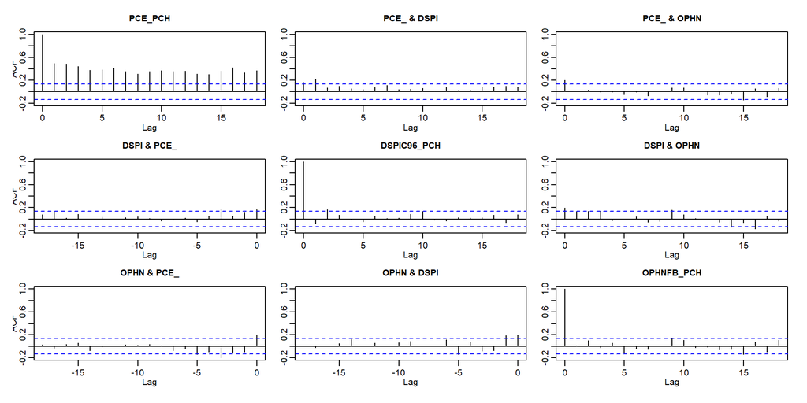

## Regressing Y on X

To forecast using this type of model, you will need “future” values of your explanatory variables.

- This is easy for some thing, and difficult for other
- Vector Autoregression (VAR)
- Impulse Response Functions (IRF)

## Regressing Y on X

OK, so estimate $Y_t = f(X_t, e_t)$!

$$\Delta GDP_t = \alpha + \beta \Delta GDP_{t-1} + \gamma \text{Spread}_{t-1} + e_t$$

But first … what about stationarity?

## Spurious Regression

Suppose you have two independent time series $y_t$ and $x_t$.

- If you regress $y_t$ on $x_t$ ($y_t = \alpha + \beta x_t + e_t$), what should $\hat{\beta}$ be?

## Spurious Regression

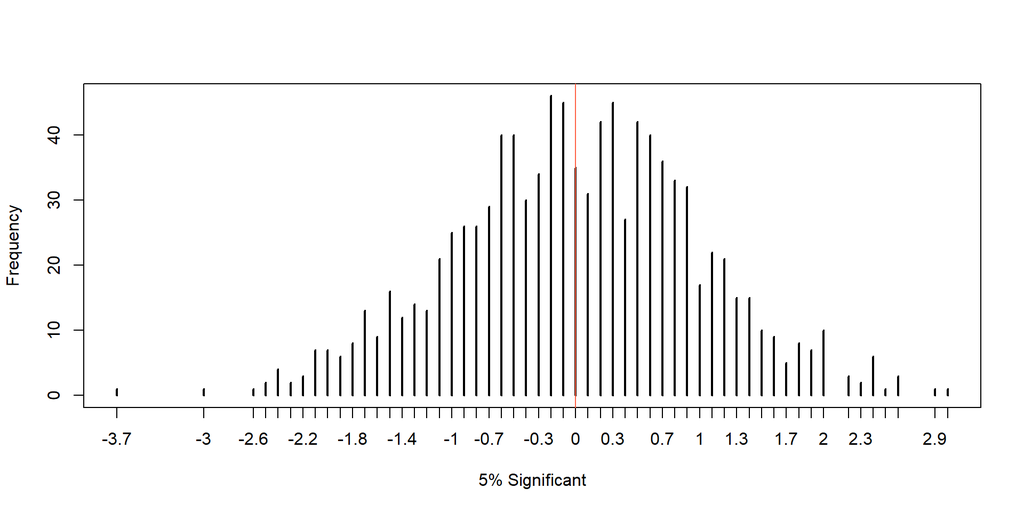

```r
tz <- c()

for(j in 1:1000){

  x <- rnorm(120)
  y <- rnorm(120)

  tz[j] <- summary(lm(y ~ x))$coefficients[2,3]
}

plot(table(round(tz, 1)),
     ylab = "Frequency",
     xlab = paste0(round(100*mean(abs(tz) > 1.96)),
                   "% Significant"))
abline(v = 0, col = "tomato")
```

## Spurious Regression

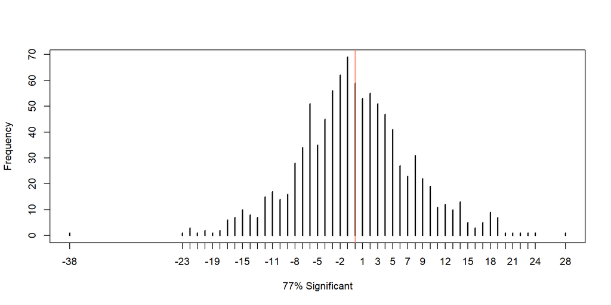

```r
for(j in 1:1000){

  x <- rep(0, 120)
  y <- rep(0, 120)

  for(i in 2:120){

    x[i] <- x[i-1] + rnorm(1)
    y[i] <- y[i-1] + rnorm(1)
  }

  tz[j] <- summary(lm(y ~ x))$coefficients[2,3]
}

plot(table(round(tz, 0)),
     ylab = "Frequency",
     xlab = paste0(round(100*mean(abs(tz) > 1.96)),
                   "% Significant"))
abline(v = 0, col = "tomato")
```

## Spurious Regression

This happens when you regress two random walks on one another.

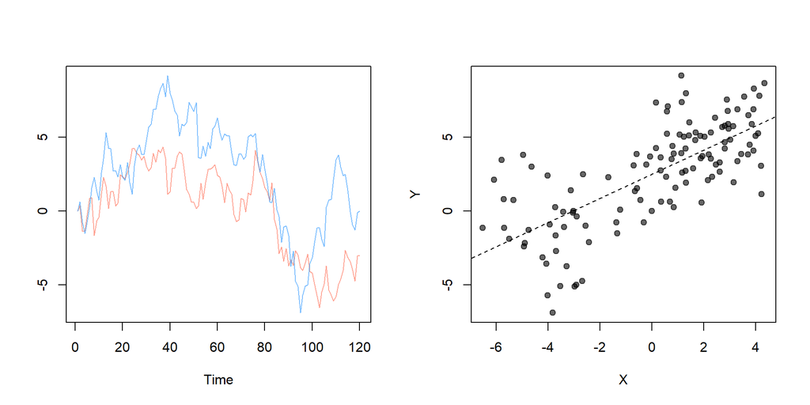

```r
par(mfrow = c(1, 2))
plot(x, type = "l", col = alpha("tomato", .6),
     xlab = "Time", ylab = "",
     ylim = range(x, y))
lines(y, col = alpha("dodgerblue", .6))
plot(x, y, pch = 19, col = alpha("black", .6),
     xlab = "X", ylab = "Y")
abline(lm(y ~ x), lty = 2)
```

## Spurious Regression

```r
reg1 <- lm(y ~ x)
t <- 2:length(y)
reg2 <- lm(y[t] ~ x[t] + y[t-1])
stargazer(reg1, reg2, type = "html")
```

|  | *Dependent variable:* |  |
| --- | --- | --- |
|  | y | y[t] |
|  | (1) | (2) |
| x | 0.818*** |  |
|  | (0.074) |  |
| x[t] |  | 0.083* |
|  |  | (0.043) |
| y[t - 1] |  | 0.905*** |
|  |  | (0.038) |
| Constant | 2.493*** | 0.238* |
|  | (0.221) | (0.132) |
| Observations | 120 | 119 |
| R<sup>2</sup> | 0.511 | 0.918 |
| Adjusted R<sup>2</sup> | 0.506 | 0.916 |
| Residual Std. Error | 2.424 (df = 118) | 1.000 (df = 116) |
| F Statistic | 123.086*** (df = 1; 118) | 647.680*** (df = 2; 116) |
| *Note:* | *p<0.1; **p<0.05;*** p<0.01 |  |

## Spurious Regression

Warnings:

1. Check stationarity of the residuals
   - Regression is spurious if residuals have a unit root.
   - `tseries::adf.test(lm(y ~ x)$residuals)`
2. Results change dramatically if lagged $y$ is included
3. If spurious, make stationary!

## Spurious Regression

```r
adf.test(reg1$residuals)
adf.test(reg2$residuals)
```

```
    Augmented Dickey-Fuller Test

data:  reg1$residuals
Dickey-Fuller = -3.0513, Lag order = 4, p-value = 0.1399
alternative hypothesis: stationary


    Augmented Dickey-Fuller Test

data:  reg2$residuals
Dickey-Fuller = -3.9078, Lag order = 4, p-value = 0.01613
alternative hypothesis: stationary
```

## Integration

Time series with unit roots are said to be integrated or $I(1)$

- $I(1)$ is unit root
- $I(0)$ is stationary
- $I(d)$ is $d$’th difference stationary
  - Hansen says $I(2)$ series are price levels and money supply

## Money Supply

[interactive chart not shown]

## Money Supply

[interactive chart not shown]

## Cointegration

Two series are *cointegrated* if a linear combination of them has a lower level of integration.

- If $Y$ and $X$ are $I(1)$, but $Y - \theta X$ is $I(0)$, they are cointegrated.
- Also consider two proportional time series.
  - If $\frac{Y}{X}$ is stationary, then $log(Y) - \theta log(X)$ is $I(0)$

Another way to think about it: two series are cointegrated if there is a (relatively) constant distance between the two.

## Cointegration

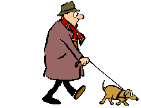

eco.uc3m.es/~jgonzalo/teaching/econometriaii/cointegration.htm

## Cointegration

Again, $y$ and $x$ are coinegrated if:

$$z_t = y_t - \theta x_t \ \ \text{is} \ \ I(0)$$

$\theta$ is sometimes known from theory

- In the case of term spread, it is $1$.
- This can also be estimated.

## Cointegration

[interactive chart not shown]

## Cointegration

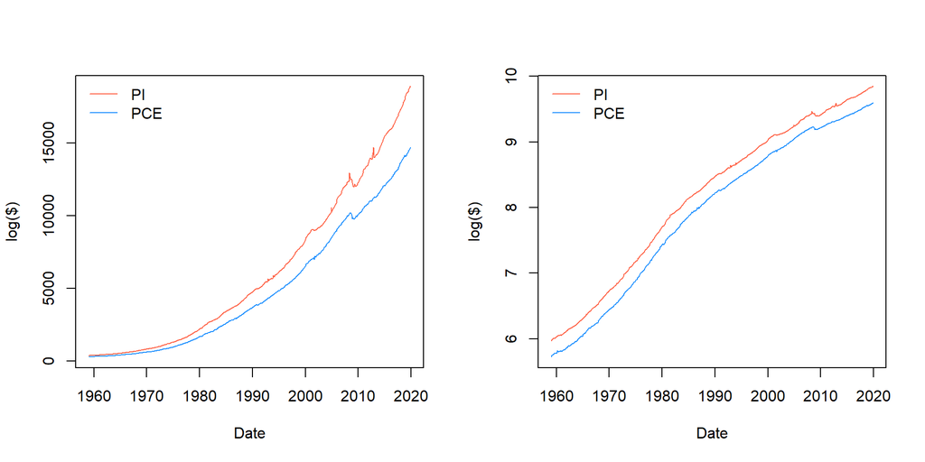

```r
pi <- read.csv("../data/inc_pce.csv")
pi$DATE <- ymd(pi$DATE)
par(mfrow = c(1, 2))
plot(pi$DATE, pi$PI, type = "l",
     ylim = range(pi$PI, pi$PCE),
     xlab = "Date", ylab = "log($)",
     col = "tomato")
lines(pi$DATE, pi$PCE, type = "l", col = "dodgerblue")
legend("topleft", legend = c("PI", "PCE"),
       col = c("tomato", "dodgerblue"),
       lty = 1, bty = "n")

plot(pi$DATE, log(pi$PI), type = "l",
     ylim = log(range(pi$PI, pi$PCE)),
     xlab = "Date", ylab = "log($)",
     col = "tomato")
lines(pi$DATE, log(pi$PCE), type = "l", col = "dodgerblue")
legend("topleft", legend = c("PI", "PCE"),
       col = c("tomato", "dodgerblue"),
       lty = 1, bty = "n")
```

## Cointegration

```r
reg <- lm(log(PCE) ~ log(PI), data = pi)
summary(reg)
```

```
Call:
lm(formula = log(PCE) ~ log(PI), data = pi)

Residuals:
      Min        1Q    Median        3Q       Max
-0.059112 -0.014470 -0.003781  0.016900  0.057097

Coefficients:
              Estimate Std. Error t value Pr(>|t|)
(Intercept) -0.3604532  0.0056156  -64.19   <2e-16 ***
log(PI)      1.0134213  0.0006801 1490.18   <2e-16 ***
---
Signif. codes:  0 '***' 0.001 '**' 0.01 '*' 0.05 '.' 0.1 ' ' 1

Residual standard error: 0.02196 on 730 degrees of freedom
Multiple R-squared:  0.9997,    Adjusted R-squared:  0.9997
F-statistic: 2.221e+06 on 1 and 730 DF,  p-value: < 2.2e-16
```

## Cointegration

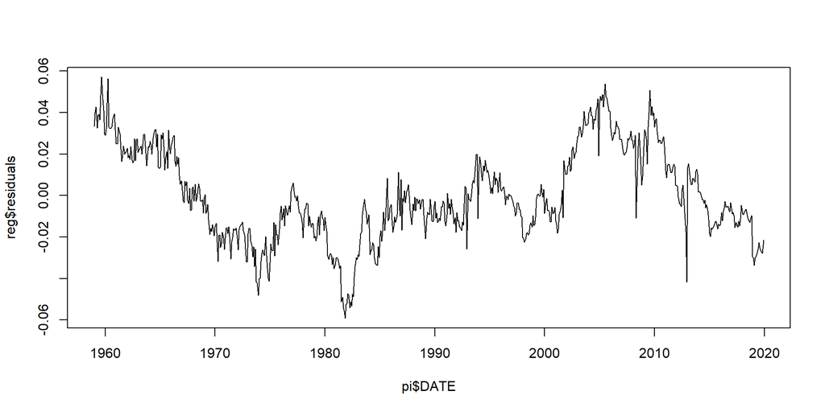

```r
plot(pi$DATE,
     reg$residuals,
     type = "l")
```

## Cointegration

```r
tseries::adf.test(reg$residuals)
```

```
    Augmented Dickey-Fuller Test

data:  reg$residuals
Dickey-Fuller = -2.9276, Lag order = 9, p-value = 0.1857
alternative hypothesis: stationary
```

## Cointegration

[interactive chart not shown]

## Cointegration

Does the comovement of the 10-Year and 3-Month indicate a spurious relationship or cointegration?

- They are both certainly non-stationary.

## Cointegration

```r
fred <- read.csv("../data/spread.csv")
fred$DATE <- ymd(fred$DATE)
fred <- fred[fred$DGS10 != ".",]
fred <- fred[fred$DATE < ymd("2014-05-01"),]
colnames(fred) <- c("DATE", "t3m", "spread", "t120m")

for(i in 2:4) fred[,i] <- as.numeric(fred[,i])

reg <- lm(t120m ~ t3m, data = fred)
summary(reg)
```

```
Call:
lm(formula = t120m ~ t3m, data = fred)

Residuals:
    Min      1Q  Median      3Q     Max
-2.1886 -0.9453 -0.0241  0.9226  3.5382

Coefficients:
            Estimate Std. Error t value Pr(>|t|)
(Intercept)  2.48633    0.08521   29.18   <2e-16 ***
t3m          0.80997    0.01450   55.86   <2e-16 ***
---
Signif. codes:  0 '***' 0.001 '**' 0.01 '*' 0.05 '.' 0.1 ' ' 1

Residual standard error: 1.123 on 626 degrees of freedom
Multiple R-squared:  0.8329,    Adjusted R-squared:  0.8326
F-statistic:  3120 on 1 and 626 DF,  p-value: < 2.2e-16
```

## Cointegration

The residuals from this regression are $z_t$!

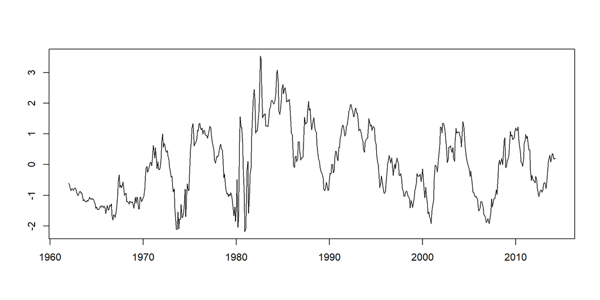

```r
plot(fred$DATE, reg$residuals, type = "l",
     xlab = "", ylab = "")
```

## Cointegration

```r
tseries::adf.test(reg$residuals)
```

```
    Augmented Dickey-Fuller Test

data:  reg$residuals
Dickey-Fuller = -3.7392, Lag order = 8, p-value = 0.02204
alternative hypothesis: stationary
```

## Cointegration

What does this have to do with spurious regression?

- Stationary: use raw series
- Non-Stationary: use differenced series
- Non-Stationary & Cointegrated: use differenced series $+$ *error correction*

## Cointegration

Error Correction Model: the change of one series is explained in terms of:

- the lag of the difference between the series
- lags of the differences of each series

$$\begin{align}\Delta y_t &= \Sigma_{i = 1}^{p} \alpha_{i} \Delta y_{t-i} \\ &+ \Sigma_{j = 1}^{q} \beta_{j} \Delta x_{t-j} \\ &+ \gamma z_{t-1} + \mu + e_t\end{align}$$

## Cointegration

$z_t$ is the residual from the $Y$ on $X$ regression.

$$Y_t = \alpha + \beta X_t + z_t$$

If $z_t$ is stationary, then $Y$ and $X$ are cointegrated.

## Cointegration

```r
t <- 2:nrow(fred)
d_t3m <- fred$t3m[t] - fred$t3m[t-1]
d_t120m <- fred$t120m[t] - fred$t120m[t-1]

t <- 2:length(d_t3m)
d_t3m_lag <- d_t3m[t-1]
d_t120m_lag <- d_t120m[t-1]
d_t3m <- d_t3m[t]
d_t120m <- d_t120m[t]

resid <- reg$residuals[2:(nrow(fred)-1)]
summary(lm(d_t120m ~ d_t120m_lag + d_t3m_lag + resid))
```

```
Call:
lm(formula = d_t120m ~ d_t120m_lag + d_t3m_lag + resid)

Residuals:
    Min      1Q  Median      3Q     Max
-1.7033 -0.1464 -0.0163  0.1495  1.4264

Coefficients:
             Estimate Std. Error t value Pr(>|t|)
(Intercept) -0.001580   0.011021  -0.143  0.88607
d_t120m_lag  0.346914   0.046645   7.437 3.42e-13 ***
d_t3m_lag   -0.051878   0.030530  -1.699  0.08977 .
resid       -0.029292   0.009943  -2.946  0.00334 **
---
Signif. codes:  0 '***' 0.001 '**' 0.01 '*' 0.05 '.' 0.1 ' ' 1

Residual standard error: 0.2757 on 622 degrees of freedom
Multiple R-squared:  0.1081,    Adjusted R-squared:  0.1038
F-statistic: 25.12 on 3 and 622 DF,  p-value: 2.364e-15
```

[figure not shown]

ECON 707/807: Econometrics II